output: html_notebook

# Exploring Prospect Loan Data by VLAD LAUKHIN

> This report explores a dataset containing information on loans and payments for approximately 114,000 customers in USA.

# Univariate Plots Section

```
## [1] 113937     81
```

```
## 'data.frame':    113937 obs. of  81 variables:
##  $ ListingKey                         : Factor w/ 113066 levels "00003546482094282EF90E5",..: 7180 7193 6647 6669 6686 6689 6699 6706 6687 6687 ...
##  $ ListingNumber                      : int  193129 1209647 81716 658116 909464 1074836 750899 768193 1023355 1023355 ...
##  $ ListingCreationDate                : Factor w/ 113064 levels "2005-11-09 20:44:28.847000000",..: 14184 111894 6429 64760 85967 100310 72556 74019 97834 97834 ...
##  $ CreditGrade                        : Factor w/ 9 levels "","A","AA","B",..: 5 1 8 1 1 1 1 1 1 1 ...
##  $ Term                               : int  36 36 36 36 36 60 36 36 36 36 ...
##  $ LoanStatus                         : Factor w/ 12 levels "Cancelled","Chargedoff",..: 3 4 3 4 4 4 4 4 4 4 ...
##  $ ClosedDate                         : Factor w/ 2803 levels "","2005-11-25 00:00:00",..: 1138 1 1263 1 1 1 1 1 1 1 ...
##  $ BorrowerAPR                        : num  0.165 0.12 0.283 0.125 0.246 ...
##  $ BorrowerRate                       : num  0.158 0.092 0.275 0.0974 0.2085 ...
##  $ LenderYield                        : num  0.138 0.082 0.24 0.0874 0.1985 ...
##  $ EstimatedEffectiveYield            : num  NA 0.0796 NA 0.0849 0.1832 ...
##  $ EstimatedLoss                      : num  NA 0.0249 NA 0.0249 0.0925 ...
##  $ EstimatedReturn                    : num  NA 0.0547 NA 0.06 0.0907 ...
##  $ ProsperRating (numeric)            : int  NA 6 NA 6 3 5 2 4 7 7 ...
```

[output cut: 67 more lines]

```
##                    ListingKey     ListingNumber
##  17A93590655669644DB4C06:     6   Min.   :      4
##  349D3587495831350F0F648:     4   1st Qu.: 400919
##  47C1359638497431975670B:     4   Median : 600554
##  8474358854651984137201C:     4   Mean   : 627886
##  DE8535960513435199406CE:     4   3rd Qu.: 892634
##  04C13599434217079754AEE:     3   Max.   :1255725
##  (Other)                :113912
##                     ListingCreationDate  CreditGrade         Term
##  2013-10-02 17:20:16.550000000:     6          :84984   Min.   :12.00
##  2013-08-28 20:31:41.107000000:     4   C      : 5649   1st Qu.:36.00
##  2013-09-08 09:27:44.853000000:     4   D      : 5153   Median :36.00
##  2013-12-06 05:43:13.830000000:     4   B      : 4389   Mean   :40.83
##  2013-12-06 11:44:58.283000000:     4   AA     : 3509   3rd Qu.:36.00
##  2013-08-21 07:25:22.360000000:     3   HR     : 3508   Max.   :60.00
##  (Other)                      :113912   (Other): 6745
##                  LoanStatus                  ClosedDate
##  Current              :56576                      :58848
##  Completed            :38074   2014-03-04 00:00:00:  105
##  Chargedoff           :11992   2014-02-19 00:00:00:  100
##  Defaulted            : 5018   2014-02-11 00:00:00:   92
##  Past Due (1-15 days) :  806   2012-10-30 00:00:00:   81
##  Past Due (31-60 days):  363   2013-02-26 00:00:00:   78
##  (Other)              : 1108   (Other)            :54633
##   BorrowerAPR       BorrowerRate     LenderYield
##  Min.   :0.00653   Min.   :0.0000   Min.   :-0.0100
##  1st Qu.:0.15629   1st Qu.:0.1340   1st Qu.: 0.1242
##  Median :0.20976   Median :0.1840   Median : 0.1730
##  Mean   :0.21883   Mean   :0.1928   Mean   : 0.1827
##  3rd Qu.:0.28381   3rd Qu.:0.2500   3rd Qu.: 0.2400
##  Max.   :0.51229   Max.   :0.4975   Max.   : 0.4925
##  NA's   :25
##  EstimatedEffectiveYield EstimatedLoss   EstimatedReturn
##  Min.   :-0.183          Min.   :0.005   Min.   :-0.183
##  1st Qu.: 0.116          1st Qu.:0.042   1st Qu.: 0.074
##  Median : 0.162          Median :0.072   Median : 0.092
##  Mean   : 0.169          Mean   :0.080   Mean   : 0.096
##  3rd Qu.: 0.224          3rd Qu.:0.112   3rd Qu.: 0.117
##  Max.   : 0.320          Max.   :0.366   Max.   : 0.284
##  NA's   :29084           NA's   :29084   NA's   :29084
```

[output cut: 193 more lines]

```
##  Min.   :    0.00                Min.   :0.7000   Min.   : 0.00000
##  1st Qu.:    0.00                1st Qu.:1.0000   1st Qu.: 0.00000
##  Median :    0.00                Median :1.0000   Median : 0.00000
##  Mean   :   25.14                Mean   :0.9986   Mean   : 0.04803
##  3rd Qu.:    0.00                3rd Qu.:1.0000   3rd Qu.: 0.00000
##  Max.   :21117.90                Max.   :1.0125   Max.   :39.00000
##
##  InvestmentFromFriendsCount InvestmentFromFriendsAmount   Investors
##  Min.   : 0.00000           Min.   :    0.00            Min.   :   1.00
##  1st Qu.: 0.00000           1st Qu.:    0.00            1st Qu.:   2.00
##  Median : 0.00000           Median :    0.00            Median :  44.00
##  Mean   : 0.02346           Mean   :   16.55            Mean   :  80.48
##  3rd Qu.: 0.00000           3rd Qu.:    0.00            3rd Qu.: 115.00
##  Max.   :33.00000           Max.   :25000.00            Max.   :1189.00
##
```

> Our dataset consists of 81 variables, with almost 114,000 observations.

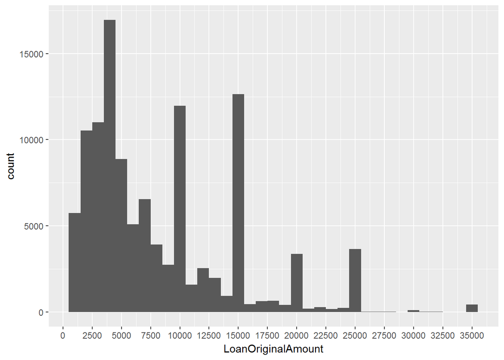

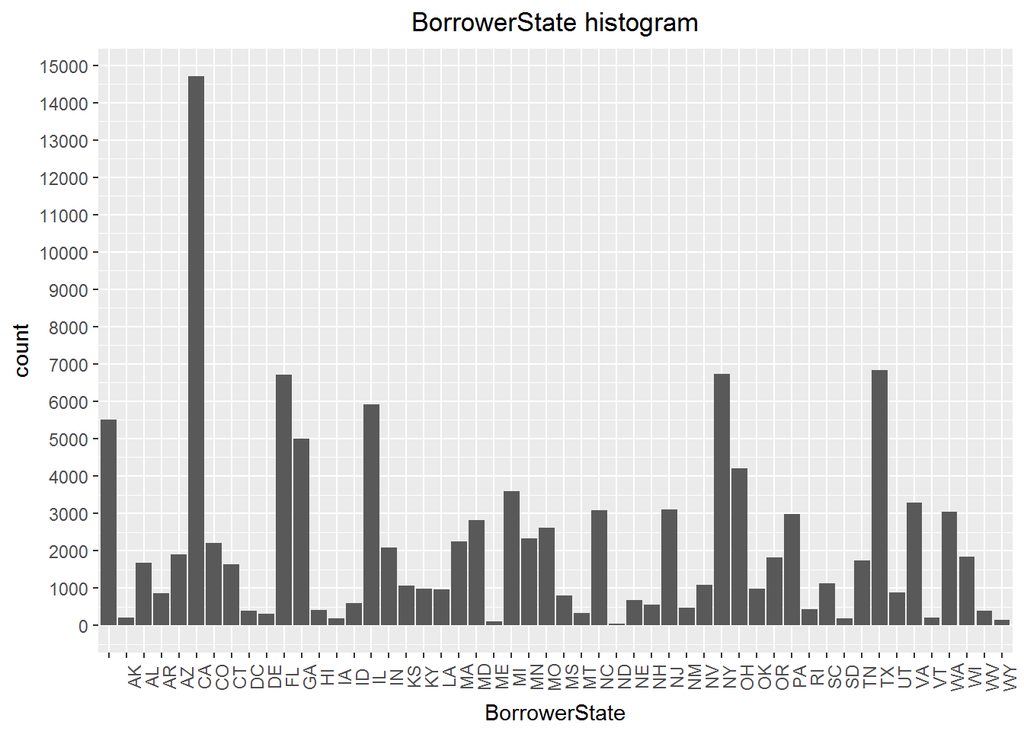

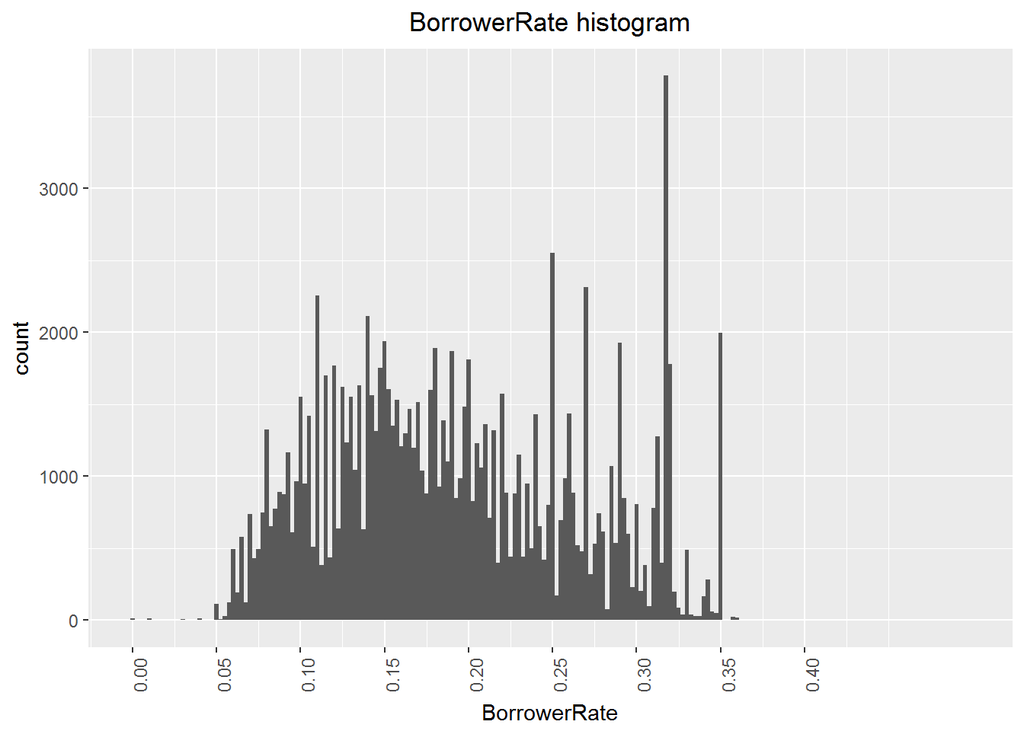

> Hm, it seems that the highest quantity of loans were given away with interest rate of around 0.32.

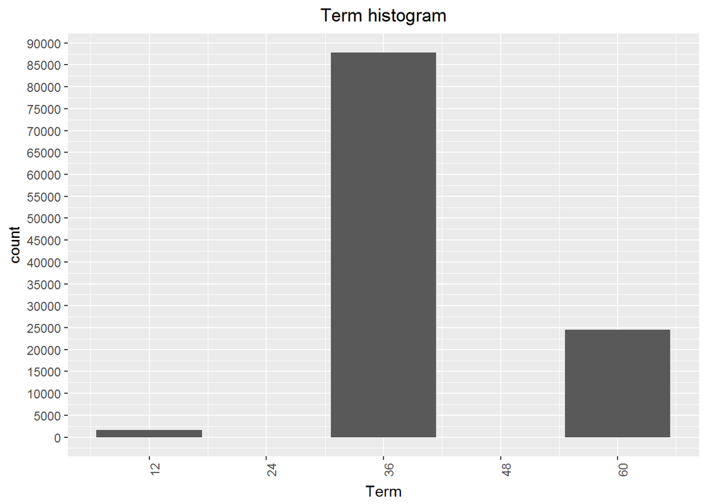

> All the loans are given for standard time of one, three, and five years, most of them are open for three years (36 months).

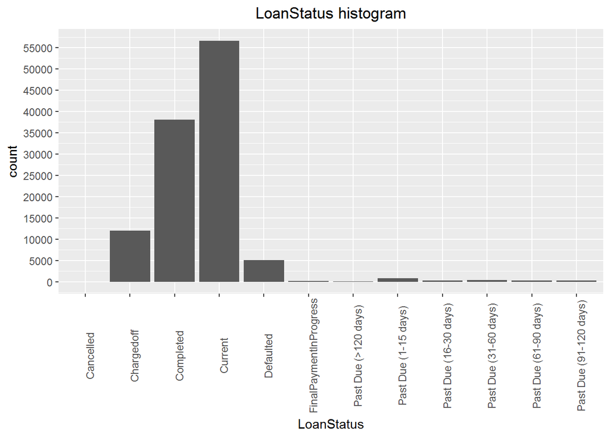

> Seems that there are lots of completed accounts as well as quite a bit of past due, defaulted, and charded offs.

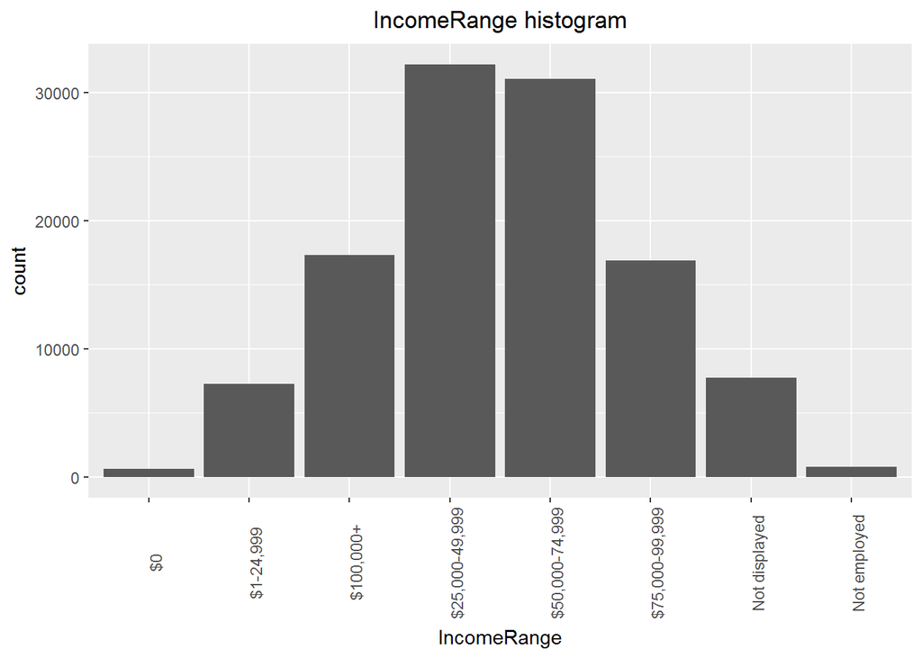

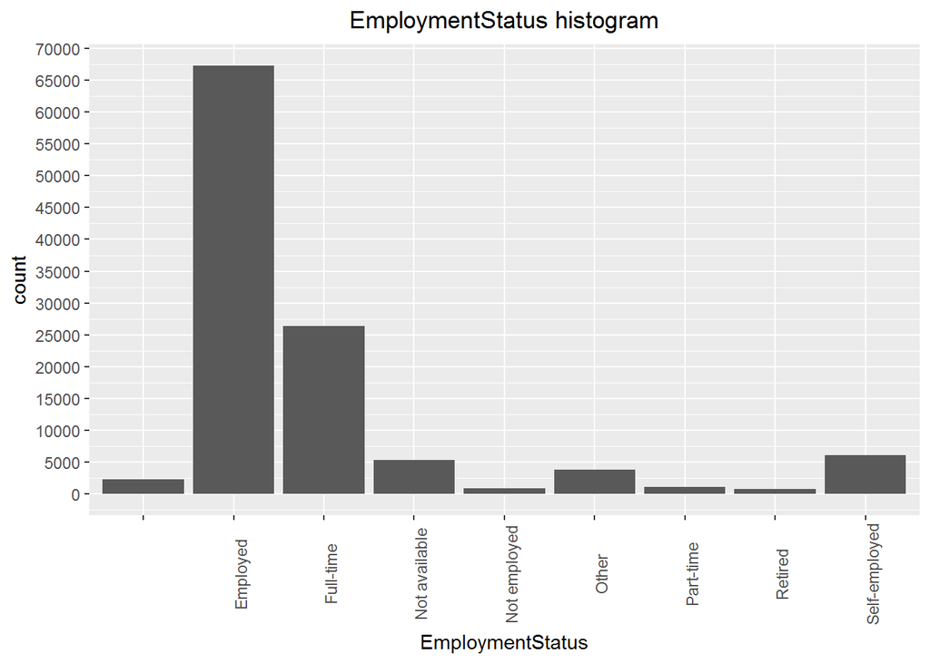

> Most of them are Employed.

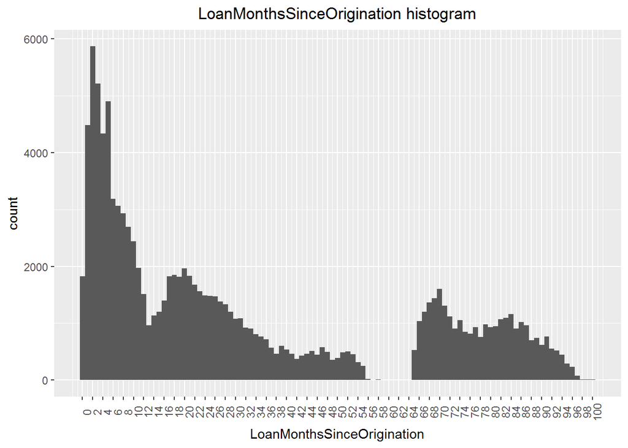

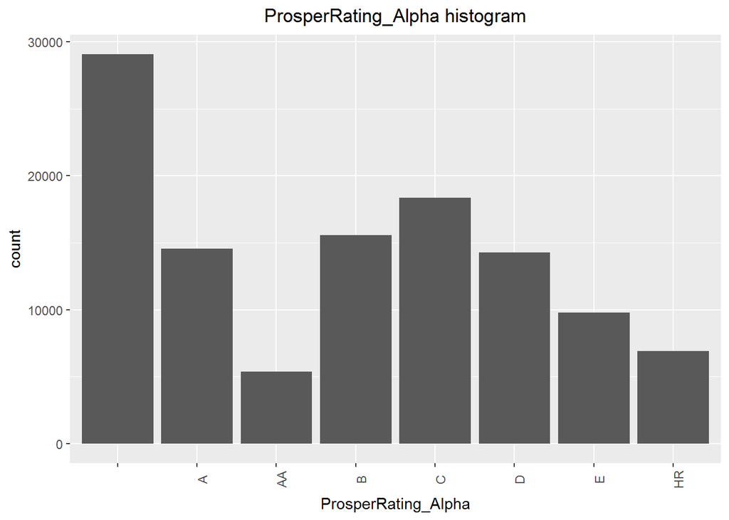

> Here we can see the distribution of prosperity rates calculated by bank for borrowers. We have the outlier of non given info in here that is about 1/4 of a data set.

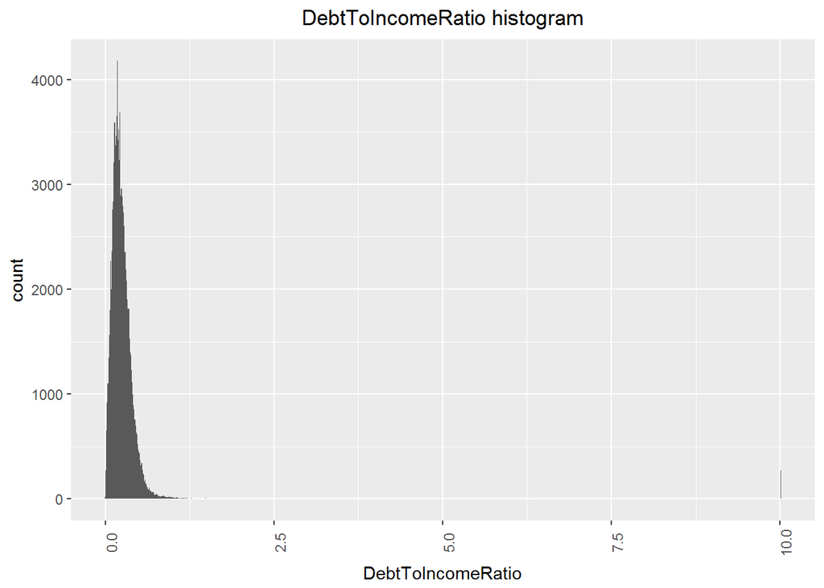

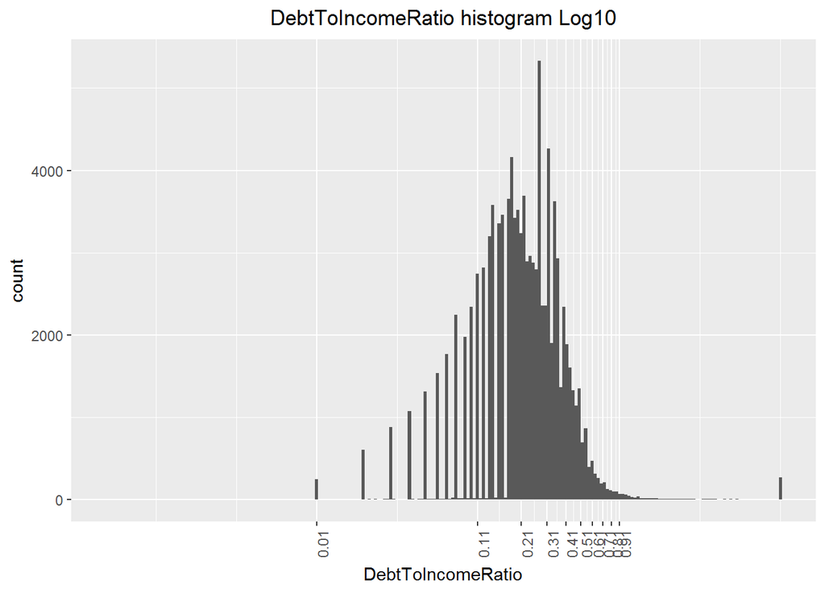

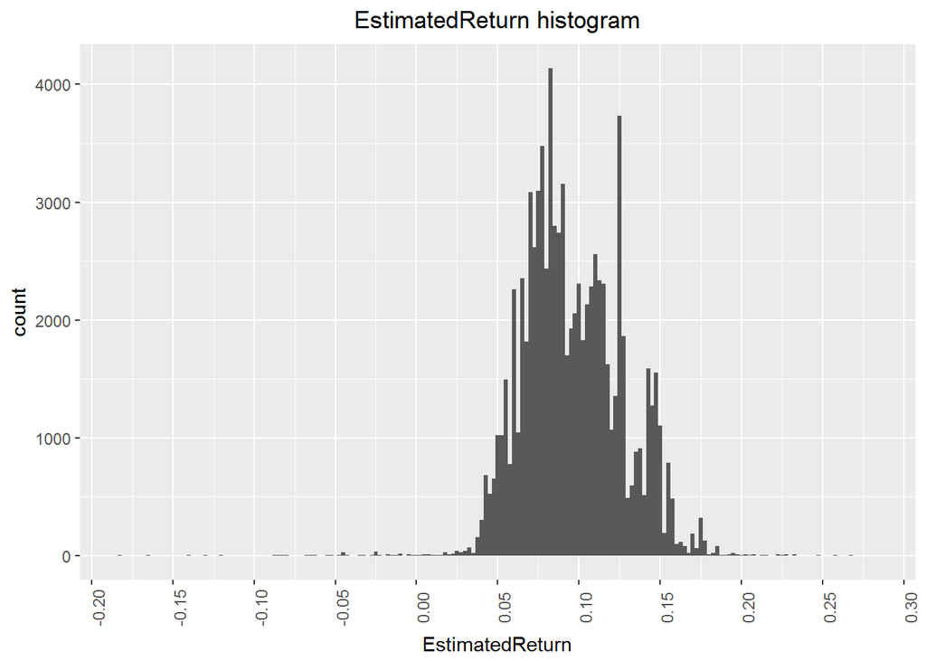

> Seems that there were 29084 rows removed that belong to customers whose loans were closed. This distribution looks normal even without transformations. Though, I think if the outliers will be removed this distribution will appear trimodal

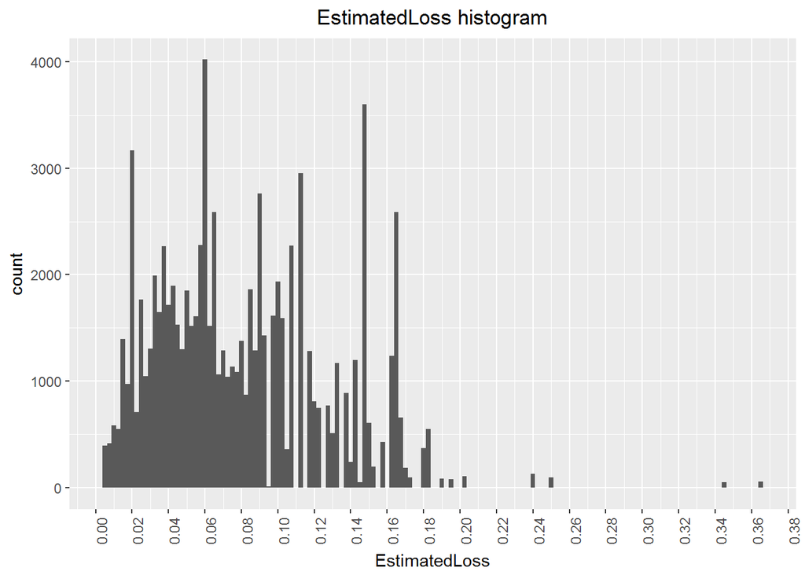

# Univariate Analysis

### What is the structure of your dataset?

> There are 113,937 loans in the dataset with 81 variables descripting loaners Status, Credit rate, Income rate, Loan ammount, Loan interest, etc. There are 20 Factor, 30 integer and 31 numeric variables. All the variable explanations could be found [here](https://docs.google.com/spreadsheets/d/1gDyi_L4UvIrLTEC6Wri5nbaMmkGmLQBk-Yx3z0XDEtI/edit#gid=0)

> The Facor variables have following levels.

| Variables | Levels |
| --- | --- |
| CreditGrade: | “A”, “AA”, “B”, “C”, “D”, “E”, “HR”, “NC”, and “”, which is not specified |
| LoanStatus: | “Cancelled”, “Chargedoff”, “Completed”, “Current”, “Defaulted”, “FinalPaymentInProgress”, “Past Due (>120 days)”, “Past Due (1-15 days)”, “Past Due (16-30 days)”,“Past Due (31-60 days)”, “Past Due (61… |
| ProsperRating (Alpha): | “A”, “AA”, “B”, “C”, “D”, “E”, “HR” and “”, which is not specified |
| EmploymentStatus: | “Employed”, “Full-time”, “Not available”, “Not employed”, “Other”, “Part-time”, “Retired”, “Self-employed” and “” which is not specified |
| IsBorrowerHomeowner: | “False”,“True” |
| CurrentlyInGroup: | “False”,“True” |
| IncomeRange: | “$0”, “$1-24,999”, “$100,000+”, “$25,000-49,999”, “$50,000-74,999”, “$75,000-99,999”, “Not displayed”, “Not employed” |
| IncomeVerifiable: | “False”,“True” |

### Other Factor variables:

| Variables | Levels |
| --- | --- |
| ClosedDate: | Factor w/ 2803 levels - Date field that should be tranformed |
| BorrowerState: | Factor w/ 52 levels - 51 State and non specified field |
| Occupation: | Factor w/ 68 levels - Borrower occupation |
| GroupKey: | Factor w/ 707 levels - The Key of the group of Borrowers membership |
| ListingKey: | Factor w/ 113066 levels - Unique key for each listing |
| ListingCreationDate: | Factor w/ 113064 levels - The date the listing was created. |
| DateCreditPulled: | Factor w/ 112992 levels -The date the credit profile was pulled. |
| FirstRecordedCreditLine: | Factor w/ 11586 levels - The date the first credit line was opened. |
| LoanKey: | Factor w/ 113066 levels - Unique key for each loan |
| LoanOriginationDate: | Factor w/ 1873 levels -The date the loan was originated. |
| LoanOriginationQuarter: | Factor w/ 33 levels -The quarter in which the loan was originated. |
| MemberKey: | Factor w/ 90831 levels - Key that is associated with the borrower. |

> There is Variable called ProsperRating (numeric). It is the same as ProsperRating (Alpha) though in numeric format. Both variables should be renamed avoiding parentheses as it might cause an error in future. Also, numeric variable ProsperRating (numeric) should be transformed to Factor.

### What is/are the main feature(s) of interest in your dataset?

> I think that the most interesting ones are income range of the borrowers, State. Loan ammount is interesting as well as we can trace the mostly common loan ammounts. As well as the BorrowerRate and how it is affecting the EstimatedLoss and EstimatedGain.

### What other features in the dataset do you think will help support your into your feature(s) of interest?

> The loan ammount and the interest rate are contributing to the timing of return. It would be interesting to trace the relationship between those two and look how it will affect reimbursment time from day one. What states are having the most of postdue or unpaid loans? What are the income rates of those who postdue?

### Did you create any new variables from existing variables in the dataset?

> 1. Renamed ProsperRating (Alpha) and ProsperRating (numeric) columns and changed ProsperRating (numeric) variable factor. Also I had to rename all the entries with no info “” to “N” as non specified.
> 2. There has been new variable **Income** created that used reduced number of factors from IncomeRange. They are “$1-24,999”, “$25,000-49,999”, “$50,000-74,999”, “$75,000-99,999”,“$100,000+”, and “$0” that combined “$0”,“Not displayed” and “Not employed”.
> 3. Also there was new variable **StatusofLoan** cretated that used reduced number of factors from LoanStatus. They are “Completed”, “Current”, “Defaulted”, “FinalPaymentInProgress”, Failed - comprising of “Cancelled”, “Chargedoff” and Past Due comprising of “Past Due (>120 days)”, “Past Due (1-15 days)”, “Past Due (16-30 days)”,“Past Due (31-60 days)”, “Past Due (61-90 days)”, “Past Due (91-120 days).

### Of the features you investigated, were there any unusual distributions?

> I had to create 2 separate variables Income and StatusofLoan to deliver a reduced number of Factors by combining those with the close-to-similar meaning. Also, I had to subset the data by eliminating records with DebtToIncomeRatio>1, EstimatedReturn<0, all the records that didn’t have BorrowerState information, and those recods that were Closed or Failed as they were not having sufficient information. Also, there were only 10 variables included in this data set.

| Variables | Description | Levels |
| --- | --- | --- |
| Term: | The length of the loan expressed in months. | N/a |
| BorrowerRate: | The Borrower’s interest rate for this loan. | N/a |
| EstimatedLoss: | Estimated loss is the estimated principal loss on charge-offs. | N/a |
| EstimatedReturn: | Estimated return is the difference between the Estimated Effective Yield and the Estimated Loss Rate. Applicable for loans originated after July 2009. | N/a |
| BorrowerState: | Factor w/ 52 levels | 51 State |
| DebtToIncomeRatio: | The debt to income ratio of the borrower at the time the credit profile was pulled. | N/a |
| LoanMonthsSinceOrigination: | Number of months since the loan originated. | N/a |
| LoanOriginalAmount: | The origination amount of the loan. | N/a |
| Income: | The income range of the borrower at the time the listing was created. | “$0”, “$1-24,999”, “$25,000-49,999”, “$50,000-74,999”, “$75,000-99,999”,“$100,000+” |
| StatusOfLoan: | The current status of the loan. | “Completed”, “Current”, “Defaulted”, “FinalPaymentInProgress”, “Failed”, “Past Due”. |

> So, the subset dataset is comprising from 84658 observations, 3 Factor and 7 numerical variables.

# Bivariate Plots Section

```
##                                Term BorrowerRate EstimatedLoss
## Term                        1.00000        0.001         -0.10
## BorrowerRate                0.00100        1.000          0.96
## EstimatedLoss              -0.10000        0.960          1.00
## EstimatedReturn             0.15000        0.850          0.68
## DebtToIncomeRatio           0.00027        0.120          0.12
## LoanMonthsSinceOrigination -0.25000        0.250          0.19
## LoanOriginalAmount          0.34000       -0.410         -0.43
##                            EstimatedReturn DebtToIncomeRatio
## Term                                 0.150           0.00027
## BorrowerRate                         0.850           0.12000
## EstimatedLoss                        0.680           0.12000
## EstimatedReturn                      1.000           0.08600
## DebtToIncomeRatio                    0.086           1.00000
## LoanMonthsSinceOrigination           0.410          -0.02500
## LoanOriginalAmount                  -0.300          -0.01700
##                            LoanMonthsSinceOrigination LoanOriginalAmount
## Term                                           -0.250              0.340
## BorrowerRate                                    0.250             -0.410
## EstimatedLoss                                   0.190             -0.430
## EstimatedReturn                                 0.410             -0.300
## DebtToIncomeRatio                              -0.025             -0.017
## LoanMonthsSinceOrigination                      1.000             -0.350
## LoanOriginalAmount                             -0.350              1.000
```

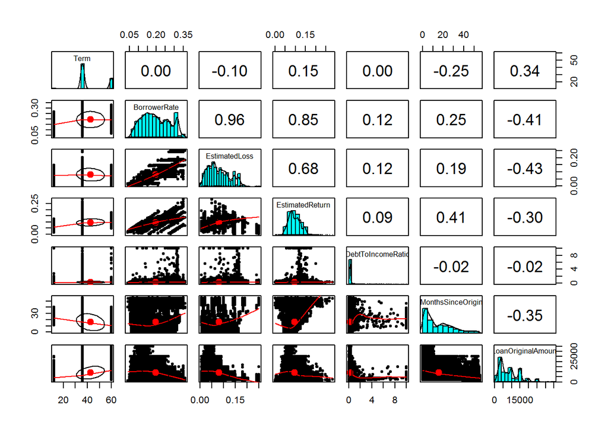

> From a subset of the data LoanOriginalAmount has moderate corellation with all variables except DebtToIncomeRatio.EstimatedLoss and EstimatedReturn have a good Correlation with BorrowerRate. Though it would be interesting to look at their interaction with other variables such as LoanOriginalAmount, DdebtToIncomeRatio, LoanMonthsSinceOrigination, Term and Income Range. Then it would be interesting to look at the same variables distribution per state.

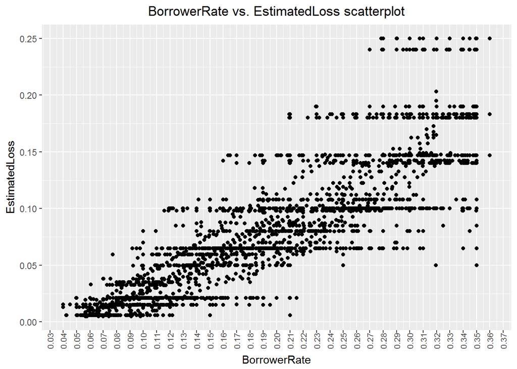

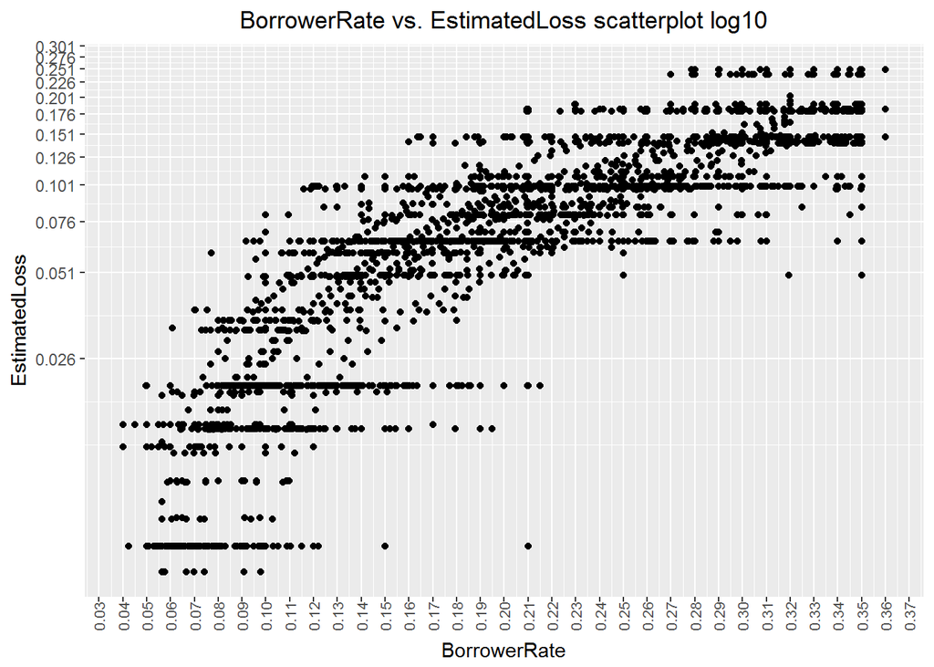

```
##
## Call:
## lm(formula = EstimatedLoss ~ BorrowerRate, data = lf_subset_expand)
##
## Residuals:
##       Min        1Q    Median        3Q       Max
## -0.120275 -0.005612  0.001727  0.006642  0.121681
##
## Coefficients:
##                Estimate Std. Error t value Pr(>|t|)
## (Intercept)  -0.0351027  0.0001234  -284.4   <2e-16 ***
## BorrowerRate  0.5867931  0.0005889   996.4   <2e-16 ***
## ---
## Signif. codes:  0 '***' 0.001 '**' 0.01 '*' 0.05 '.' 0.1 ' ' 1
##
## Residual standard error: 0.01278 on 84656 degrees of freedom
## Multiple R-squared:  0.9214, Adjusted R-squared:  0.9214
## F-statistic: 9.927e+05 on 1 and 84656 DF,  p-value: < 2.2e-16
```

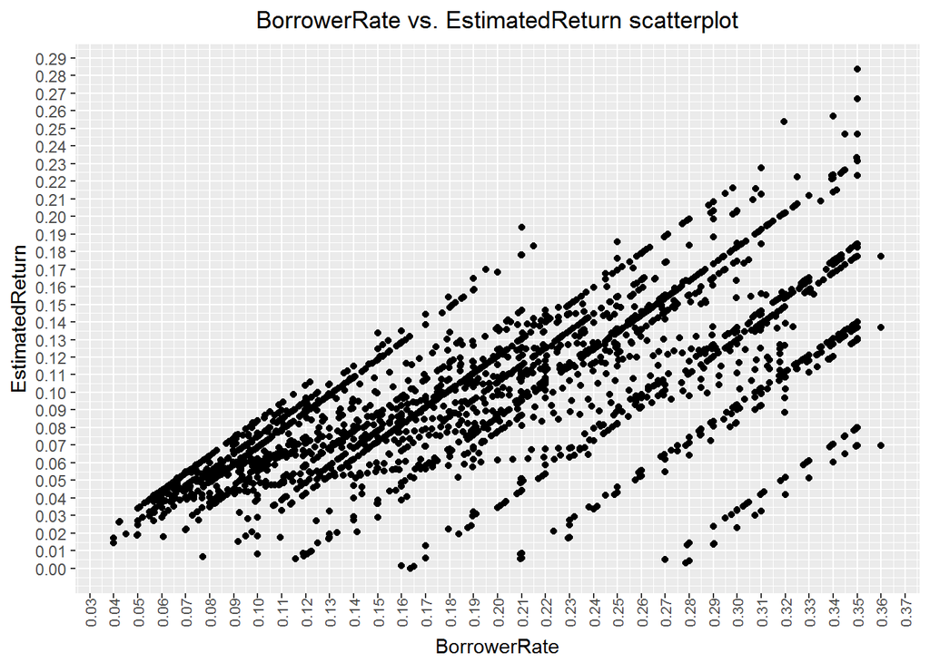

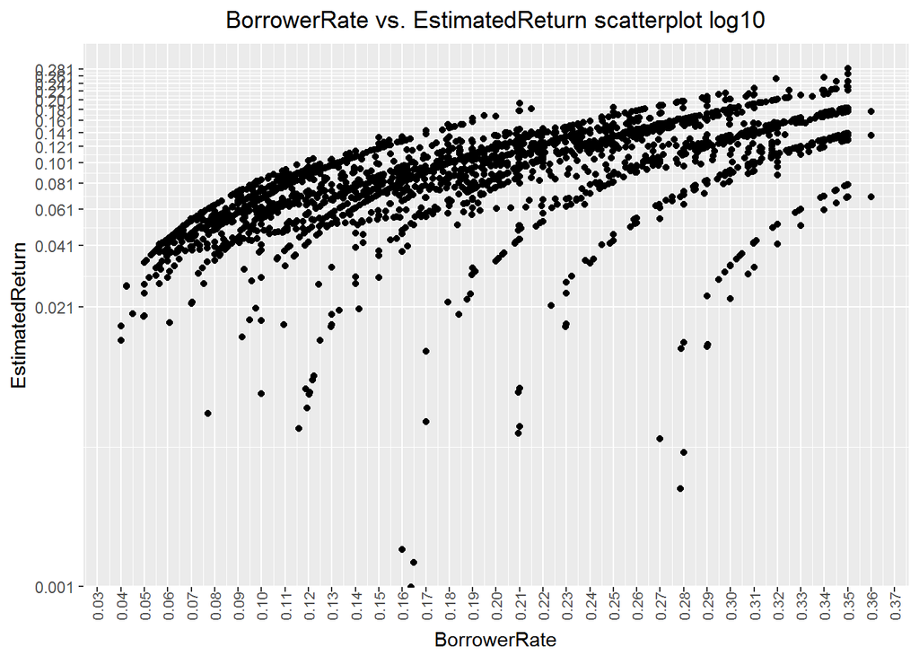

> The same observation could be made on BorrowerRate vs EstimatedReturn. It has nonlinear relationship (exponential). We have funnel like distribution of EstimatedLoss with increase of BorrowerRate at lower BorrowerRate and after logtransforming EstimatedLoss we can see the nonlinear bands where many of BorrowerRate points are following the increase in EstimatedReturn.

```
##
## Call:
## lm(formula = EstimatedReturn ~ BorrowerRate, data = lf_subset_expand)
##
## Residuals:
##       Min        1Q    Median        3Q       Max
## -0.121479 -0.008893 -0.002077  0.008098  0.135111
##
## Coefficients:
##               Estimate Std. Error t value Pr(>|t|)
## (Intercept)  0.0300793  0.0001488   202.1   <2e-16 ***
## BorrowerRate 0.3386001  0.0007100   476.9   <2e-16 ***
## ---
## Signif. codes:  0 '***' 0.001 '**' 0.01 '*' 0.05 '.' 0.1 ' ' 1
##
## Residual standard error: 0.0154 on 84656 degrees of freedom
## Multiple R-squared:  0.7287, Adjusted R-squared:  0.7287
## F-statistic: 2.274e+05 on 1 and 84656 DF,  p-value: < 2.2e-16
```

> Despite the fact that the relationship looks nonlinear, based on the R^2 value, BorrowerRate still explains about 92 percent of the variance in EstimatedLoss and 72 percent in EstimatedReturn.

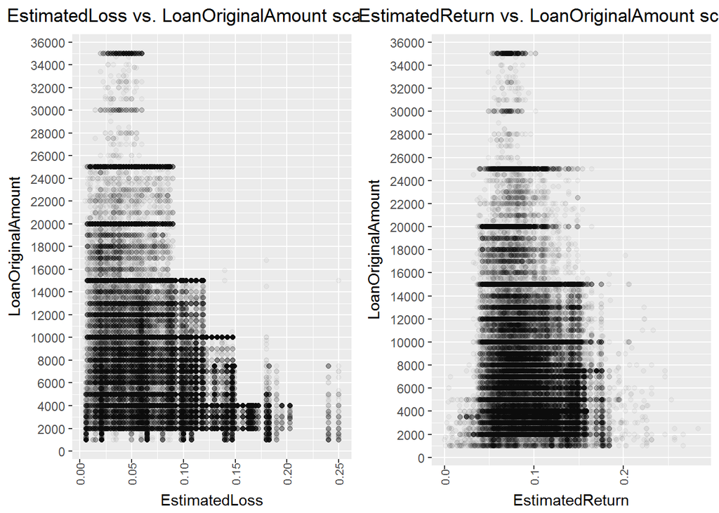

> When comparing EstimatedLoss and EstimatedReturn to LoanOriginalAmount I had to reduce the overplotting with jitter and transparency level. Most of the EstimatedLoss belongs to the loan amounts of 2000 - 25000. Most of the EstimatedReturn belongs to the loan amounts of 1000 - 25000. Also those two plots are showwing a lack of good correlation between those variables.

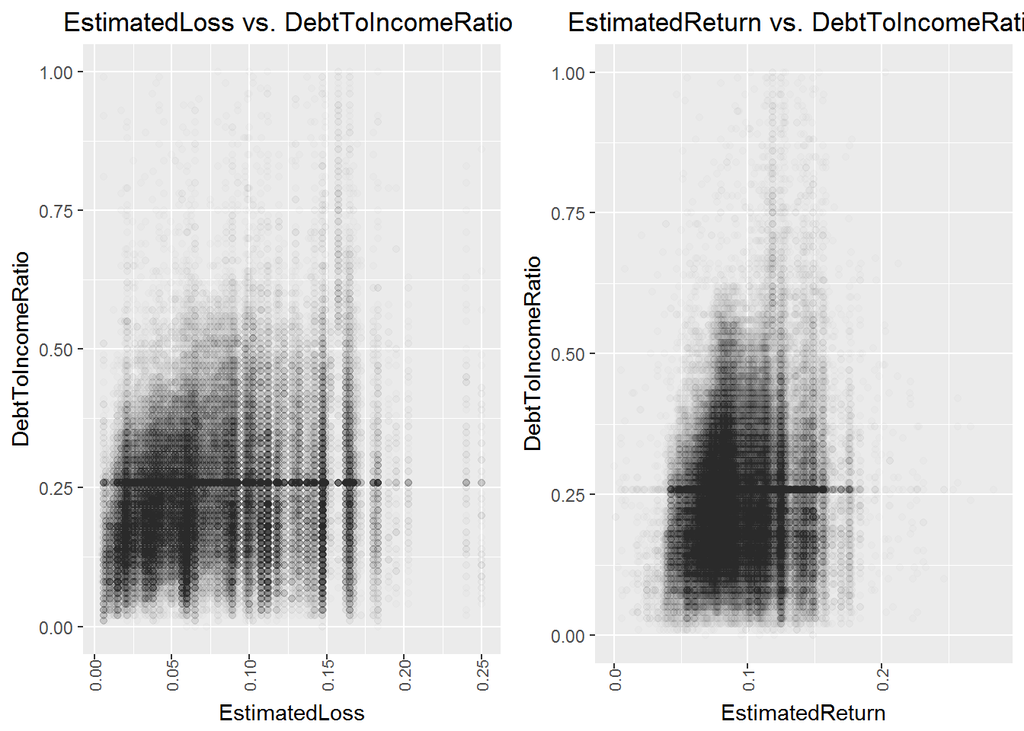